# Chapter 2

Praveen kumar

November 7, 2018

# Introduction to R

## Basic commmands

R uses functions to perform operations. To run a function called funcname, we type funcname(input1, input2), where the inputs (or arguments) input1 and input2 tell R how to run the function. A function can have any number of inputs. For example, to create a vector of numbers, we use the function c() (for concatenate). Any numbers inside the parentheses are joined together. The following command instructs R to join together the numbers 1, 3, 2, and 5, and to save them as a vector named x. When we type x, it gives us back the vector.

```r
x <- c(1,3,2,5)
print(x)
```

```
## [1] 1 3 2 5
```

The same thing can also be done using ‘=’ sign (without single quotation) intead of using ‘<-’.

```r
y = c(1,2,4,5)
print(y)
```

```
## [1] 1 2 4 5
```

In addition, typing ?funcname will always cause R to open a new help file window with additional information about the function funcname. We can tell R to add two sets of numbers together. It will then add the first number from x to the first number from y, and so on. However, x and y should be the same length. We can check their length using the length() function.

```r
length(x)
```

```
## [1] 4
```

```r
length(y)
```

```
## [1] 4
```

```r
print(x+y)
```

```
## [1]  2  5  6 10
```

The ls() function allows us to look at a list of all of the objects, such as data and functions, that we have saved so far. The rm() function can be used to delete any that we don’t want.

```r
ls()
```

```
## [1] "x" "y"
```

```r
rm(y)
#it is also possible to remove all objets at once.
#rm(list=ls())
```

The matrix() function can be used to create a matrix of numbers. Before we use the matrix() function, we can learn more about it:

```r
?matrix
```

```
## starting httpd help server ... done
```

The help file reveals that the matrix() function takes a number of inputs, but for now we focus on the first three: the data (the entries in the matrix), the number of rows, and the number of columns. First, we create a simple matrix.

```r
x <- matrix(data = c(1,2,3,4,5,6),nrow = 3,ncol = 2)
print(x)
```

```
##      [,1] [,2]
## [1,]    1    4
## [2,]    2    5
## [3,]    3    6
```

Note that we could just as well omit typing data=, nrow=, and ncol= in the matrix() command above: that is, we could just type

```r
x <- matrix(c(1,2,3,4,5,6),3,2)
print(x)
```

```
##      [,1] [,2]
## [1,]    1    4
## [2,]    2    5
## [3,]    3    6
```

and this would have the same effect. However, it can sometimes be useful to specify the names of the arguments passed in, since otherwise R will assume that the function arguments are passed into the function in the same order that is given in the function’s help file. As this example illustrates, by default R creates matrices by successively filling in columns. Alternatively, the byrow=TRUE option can be used to populate the matrix in order of the rows.

```r
x <- matrix(c(1,2,3,4,5,6),3,2,byrow = TRUE)
print(x)
```

```
##      [,1] [,2]
## [1,]    1    2
## [2,]    3    4
## [3,]    5    6
```

```r
print(sqrt(x))
```

```
##          [,1]     [,2]
## [1,] 1.000000 1.414214
## [2,] 1.732051 2.000000
## [3,] 2.236068 2.449490
```

```r
print(x^2)
```

```
##      [,1] [,2]
## [1,]    1    4
## [2,]    9   16
## [3,]   25   36
```

The rnorm() function generates a vector of random normal variables, with first argument n the sample size. Each time we call this function, we will get a different answer. Here we create two correlated sets of numbers, x and y, and use the cor() function to compute the correlation between them.

```r
x <- rnorm(100)
y <- x+rnorm(100,mean = 50, sd = 0.1)
cor(x,y)
```

```
## [1] 0.9942744
```

By default, rnorm() creates standard normal random variables with a mean of 0 and a standard deviation of 1. However, the mean and standard deviation can be altered using the mean and sd arguments, as illustrated above. Sometimes we want our code to reproduce the exact same set of random numbers; we can use the set.seed() function to do this. The set.seed() function takes an (arbitrary) integer argument.

```
set.seed(1200)
rnorm(50)
```

We use set.seed() throughout the labs whenever we perform calculations involving random quantities. In general this should allow the user to reproduce our results. However, it should be noted that as new versions of R become available it is possible that some small discrepancies may form between the book and the output from R. The mean() and var() functions can be used to compute the mean and variance of a vector of numbers. Applying sqrt() to the output of var() will give the standard deviation. Or we can simply use the sd() function.

```r
set.seed(3)
y <- rnorm(100)
print(mean(y))
```

```
## [1] 0.01103557
```

```r
print(var(y))
```

```
## [1] 0.7328675
```

```r
print(sd(y))
```

```
## [1] 0.8560768
```

```r
print(sqrt(sd(y)))
```

```
## [1] 0.9252442
```

## Graphics in R

The plot() function is the primary way to plot data in R. For instance, plot(x,y) produces a scatterplot of the numbers in x versus the numbers in y. There are many additional options that can be passed in to the plot() function. For example, passing in the argument xlab will result in a label on the x-axis. To find out more information about the plot() function, type ?plot.

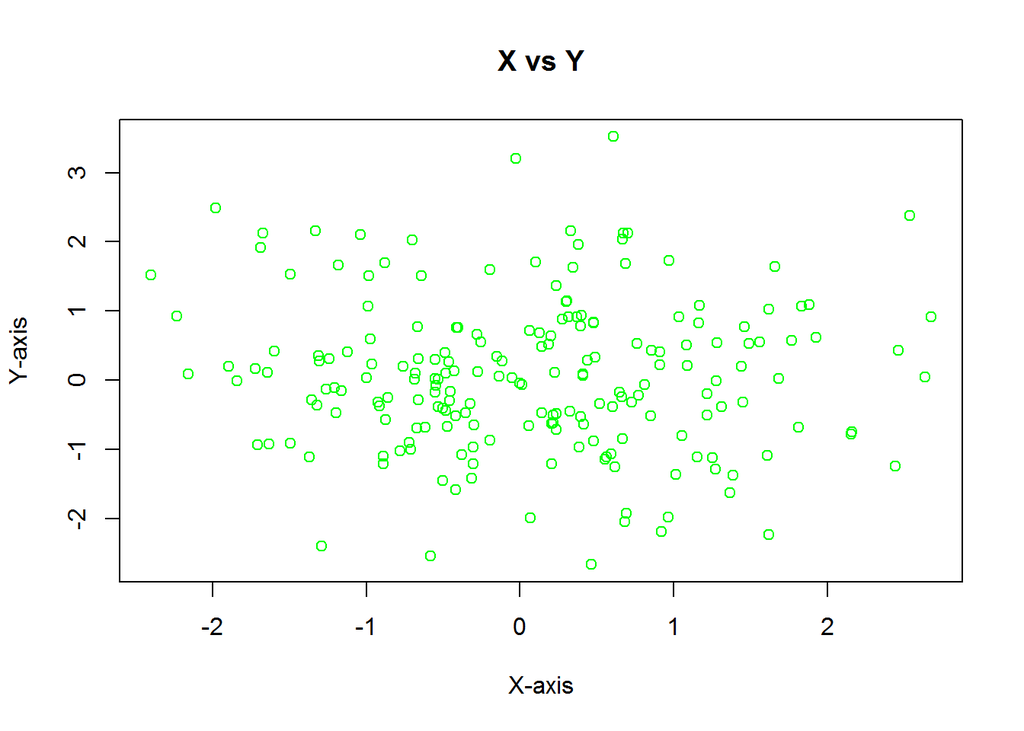

```r
x <- rnorm(200)
y <- rnorm(200)
plot(x,y,xlab = "X-axis",ylab = "Y-axis",main = "X vs Y",col='green')
```

We will often want to save the output of an R plot. The command that we use to do this will depend on the file type that we would like to create. For instance, to create a pdf, we use the pdf() function, and to create a jpeg, we use the jpeg() function.

```r
pdf("figure.pdf")
plot(x,y,col="red")
dev.off()
```

The function dev.off() indicates to R that we are done creating the plot. Alternatively, we can simply copy the plot window and paste it into an appropriate file type, such as a Word document. The function seq() can be used to create a sequence of numbers. For instance, seq(a,b) makes a vector of integers between a and b. There are many other options: for instance, seq(0,1,length=10) makes a sequence of 10 numbers that are equally spaced between 0 and 1. Typing 3:11 is a shorthand for seq(3,11) for integer arguments.

```r
x<- seq(1,10)
print(x)
```

```
##  [1]  1  2  3  4  5  6  7  8  9 10
```

```r
x<- 1:10
print(x)
```

```
##  [1]  1  2  3  4  5  6  7  8  9 10
```

```r
x <- seq(-pi,pi,length=50)
print(x)
```

```
##  [1] -3.14159265 -3.01336438 -2.88513611 -2.75690784 -2.62867957
##  [6] -2.50045130 -2.37222302 -2.24399475 -2.11576648 -1.98753821
## [11] -1.85930994 -1.73108167 -1.60285339 -1.47462512 -1.34639685
## [16] -1.21816858 -1.08994031 -0.96171204 -0.83348377 -0.70525549
## [21] -0.57702722 -0.44879895 -0.32057068 -0.19234241 -0.06411414
## [26]  0.06411414  0.19234241  0.32057068  0.44879895  0.57702722
## [31]  0.70525549  0.83348377  0.96171204  1.08994031  1.21816858
## [36]  1.34639685  1.47462512  1.60285339  1.73108167  1.85930994
## [41]  1.98753821  2.11576648  2.24399475  2.37222302  2.50045130
## [46]  2.62867957  2.75690784  2.88513611  3.01336438  3.14159265
```

We will now create some more sophisticated plots. The contour() funccontour() tion produces a contour plot in order to represent three-dimensional data; it is like a topographical map. It takes three arguments:

- A vector of the x values (the first dimension),
- A vector of the y values (the second dimension), and
- A matrix whose elements correspond to the z value (the third dimension) for each pair of (x,y) coordinates.  
  As with the plot() function, there are many other inputs that can be used to fine-tune the output of the contour() function. To learn more about these, take a look at the help file by typing ?contour.

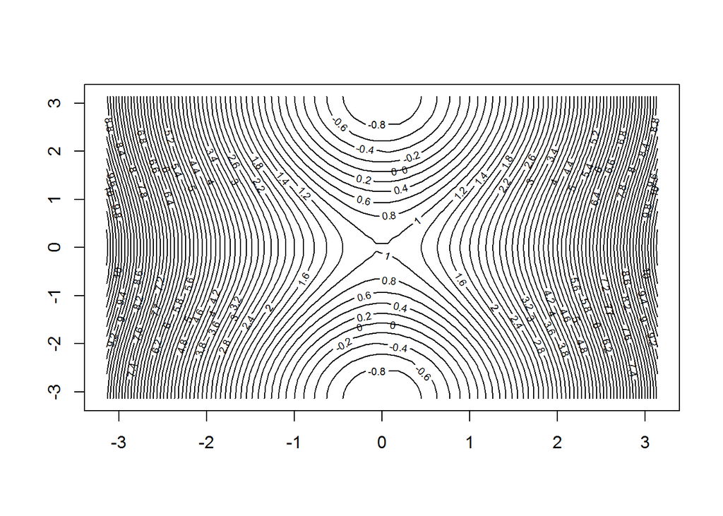

```r
y = x
f = outer(X = x,Y = y,FUN = function(x,y)cos(y)/1+x^2)
contour(x,y,f)
contour(x,y,f,nlevels = 45,add = T)
```

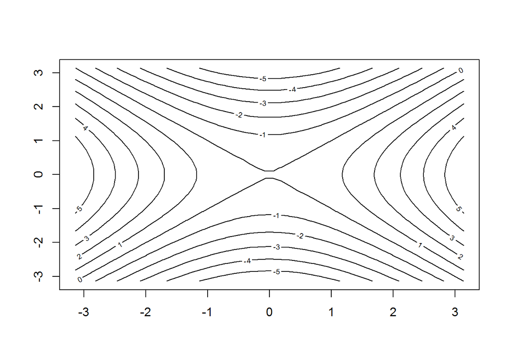

```r
fa = (f-t(f))/2
contour(x,y,fa,nlevels = 15)
```

The image() function works the same way as contour(), except that it produces a color-coded plot whose colors depend on the z value. This is knows as *heatmaps*, and is sometimes used to plot temperature in weather forecasts. Alternatively, persp() can be used to produce a three-dimensional plot. The arguments theta and phi control the angles at which the plot is viewed.

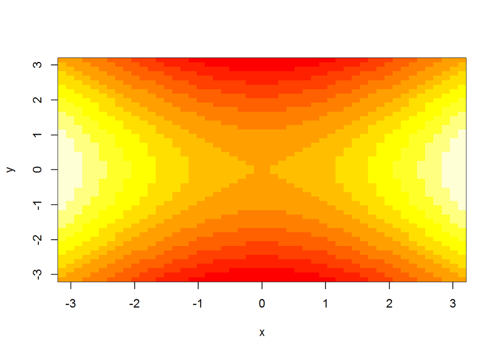

```r
image(x,y,fa)
```

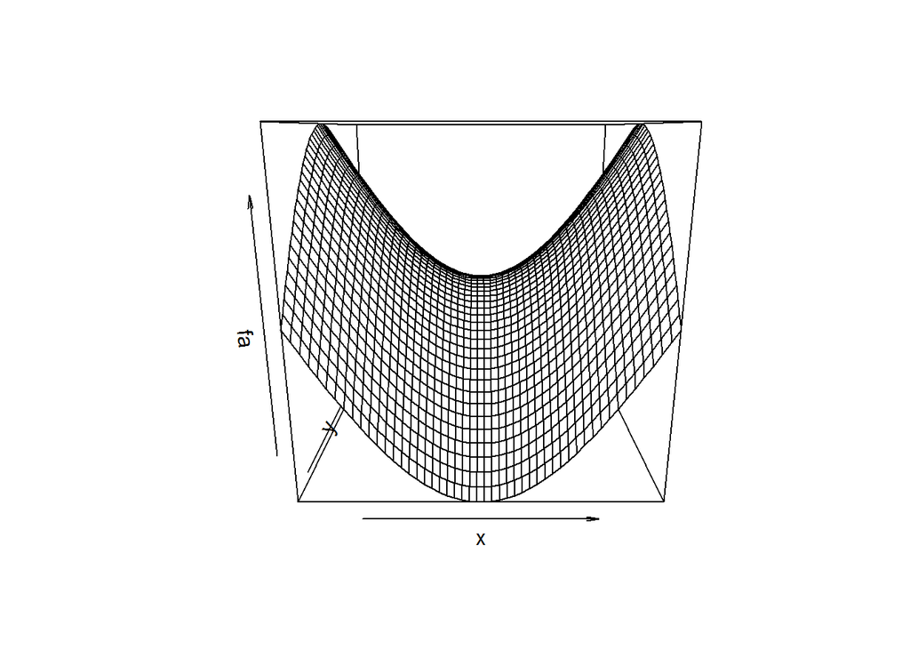

```r
persp(x,y,fa)
```

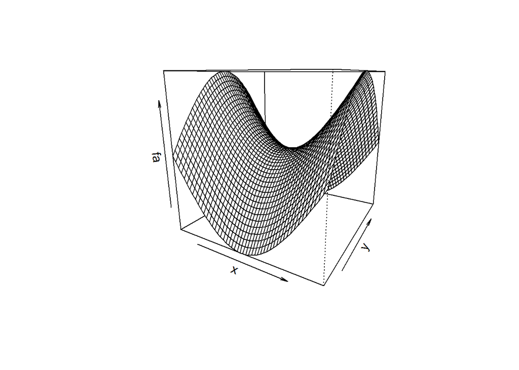

```r
persp(x,y,fa,theta = 30)
```

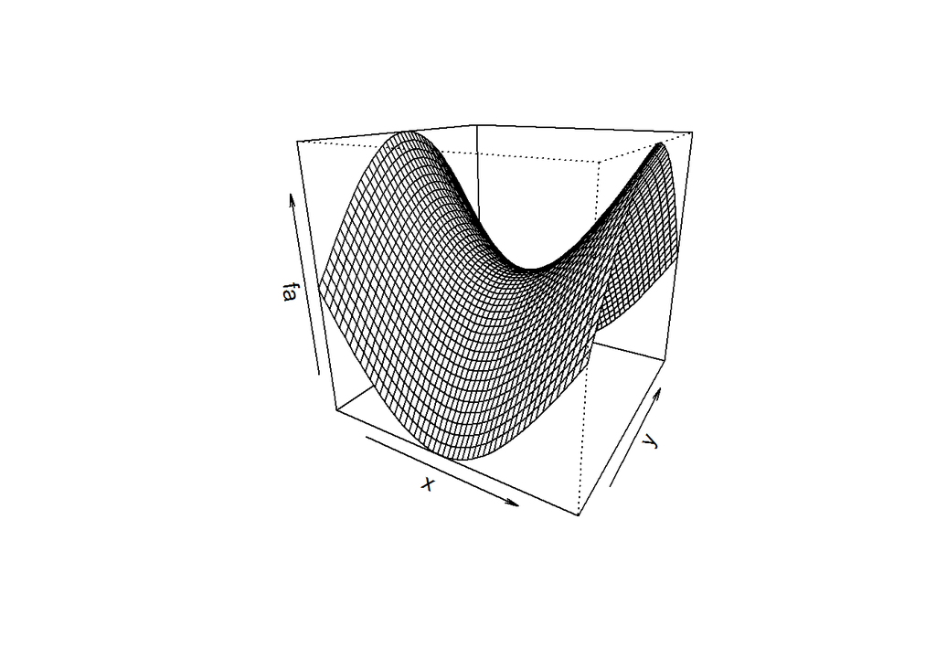

```r
persp(x,y,fa,theta = 30,phi = 20)
```

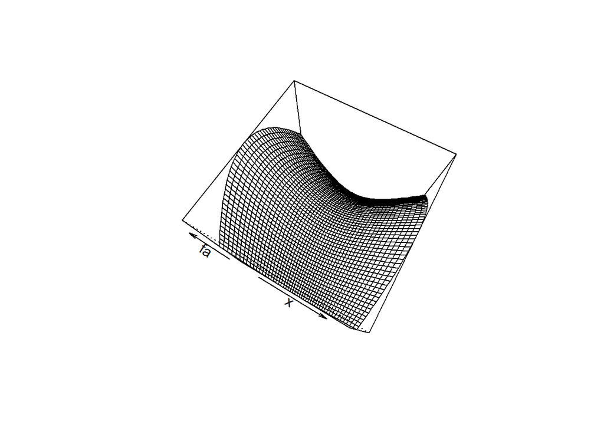

```r
persp(x,y,fa,theta = 30,phi = 70)
```

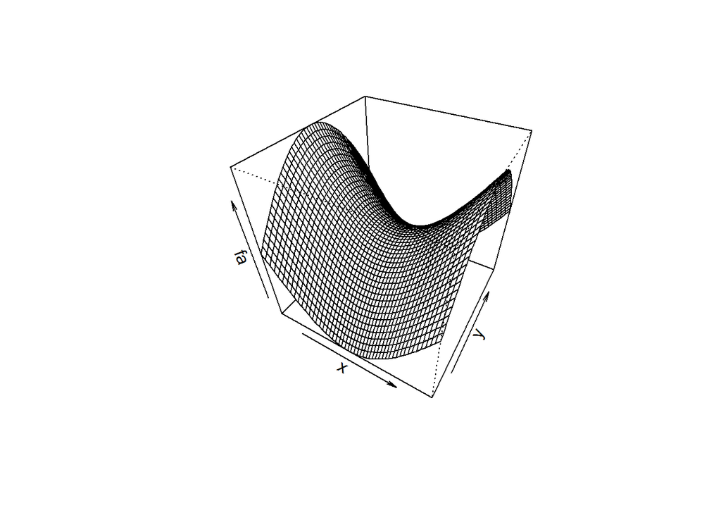

```r
persp(x,y,fa,theta = 30,phi = 40)
```